# Effects of severe weather events in US on health and economy

## Synopsis

In this analysis I explore the effects of severe weather events in the US on health and economy. Tornados are by far the most harmfull types of events across the United States, with respect to population health. Floods are the event types with the greatest economic consequences.

## Data Processing

First I load the [StormData](https://d396qusza40orc.cloudfront.net/repdata%2Fdata%2FStormData.csv.bz2).

```r
#Download and unzip the data file
#https://d396qusza40orc.cloudfront.net/repdata%2Fdata%2FStormData.csv.bz2
address <- "https://d396qusza40orc.cloudfront.net/repdata%2Fdata%2FStormData.csv.bz2"
address <- sub("^https", "http", address) #https does not work
zipname <- "StormData.csv.bz2"
download.file(address,zipname)

#No need to unzip, R can is smart enough to read a zipped csv
stormdata <- read.csv(zipname)

#housekeeping - remove the zip as it is no longer needed
file.remove(zipname)
```

```
## [1] TRUE
```

```r
#housekeeping
rm(address, zipname)
```

Some more data preparation. I add a column called HEALTH that contains the number of people affected. I include both the fatalities and the injuries, i.e. the fataly and non-fataly injured. Secondly I add a column for the damages in dollars. For this I need to combine the columns with numbers and columns with alphabetical indictation, for the severity, “K” for thousands of dollars, “M” for millions, “B” for billions. Thirdly, I add a column for year. The first years a scarcely filled with data and inculde only data for a small number of event types. From the nineties onwards, there is a more complete set.

```r
#Add a health column
#This includes all those that are affected, i.e. killed or injured
stormdata$HEALTH <- stormdata$FATALITIES + stormdata$INJURIES

#Add a column that adds up the prop and crop damage
#Start with all zeros and then add propdmg and cropdmg multiplied by
#the correct number depending on "K", "M" or "B"
K <- 1000
M <- 1000000
B <- 1000000000

#Set damage to all zeros
stormdata$DAMAGE <- 0

#Add PROPDMG thousands, millions and billions
stormdata$DAMAGE[toupper(stormdata$PROPDMGEXP)=="K"] <-
  stormdata$DAMAGE[toupper(stormdata$PROPDMGEXP)=="K"] +
  stormdata$PROPDMG[toupper(stormdata$PROPDMGEXP)=="K"] * K
stormdata$DAMAGE[toupper(stormdata$PROPDMGEXP)=="M"] <-
  stormdata$DAMAGE[toupper(stormdata$PROPDMGEXP)=="M"] +
  stormdata$PROPDMG[toupper(stormdata$PROPDMGEXP)=="M"] * M
stormdata$DAMAGE[toupper(stormdata$PROPDMGEXP)=="B"] <-
  stormdata$DAMAGE[toupper(stormdata$PROPDMGEXP)=="B"] +
  stormdata$PROPDMG[toupper(stormdata$PROPDMGEXP)=="B"] * B

#Add CROPDMG thousands, millions and billions
stormdata$DAMAGE[toupper(stormdata$CROPDMGEXP)=="K"] <-
  stormdata$DAMAGE[toupper(stormdata$CROPDMGEXP)=="K"] +
  stormdata$CROPDMG[toupper(stormdata$CROPDMGEXP)=="K"] * K
stormdata$DAMAGE[toupper(stormdata$CROPDMGEXP)=="M"] <-
  stormdata$DAMAGE[toupper(stormdata$CROPDMGEXP)=="M"] +
  stormdata$CROPDMG[toupper(stormdata$CROPDMGEXP)=="M"] * M
stormdata$DAMAGE[toupper(stormdata$CROPDMGEXP)=="B"] <-
  stormdata$DAMAGE[toupper(stormdata$CROPDMGEXP)=="B"] +
  stormdata$CROPDMG[toupper(stormdata$CROPDMGEXP)=="B"] * B

#house keeping
rm(K, M , B)

#Use library lubridate
#Only the data for more recent years is relevant
library(lubridate)

#Add a YEAR colum to the data
stormdata$YEAR <- year(mdy_hms(stormdata$BGN_DATE))

#Take into account only the years for which we have more complete data
#I set the year to be larger or equal to 1995
complete_year <- 1995
stormdata <- stormdata[which(stormdata$YEAR >= complete_year),]

#I only need to keep the rows where the health impact > 0
#or the damage > 0
stormdata <- stormdata[which(stormdata$HEALTH > 0 |
                             stormdata$DAMAGE > 0),]


#unique(stormdata$EVTYPE)
#house keeping
rm(complete_year)
```

Some more, slightly tedious, clean-up work needs to be done. The EVTYPE names are a mees and need to be renamed to the relevant official event type name. I assign each variant to an official event type.

```r
#copy the event types to a vector:
#turn levels into character, trim whitespaces and make all lowercase
e <- tolower(trimws(as.character(stormdata$EVTYPE)))

#now some brute force replacing
#all variants remaining in the data have been mapped
e[which(e=="agricultural freeze")] <- "Frost/Freeze (Z)"
e[which(e=="astronomical high tide")] <- "Storm Tide (Z)"
e[which(e=="astronomical low tide")] <- "Astronomical Low Tide (Z)"
e[which(e=="avalanche")] <- "Avalanche (Z)"
e[which(e=="beach erosion")] <- "Coastal Flood (Z)"
e[which(e=="black ice")] <- "Sleet (Z)"
e[which(e=="blizzard")] <- "Blizzard (Z)"
e[which(e=="blowing dust")] <- "Dust Storm (Z)"
e[which(e=="blowing snow")] <- "Winter Storm (Z)"
e[which(e=="brush fire")] <- "Wildfire (Z)"
e[which(e=="coastal erosion")] <- "Coastal Flood (Z)"
e[which(e=="coastal flood")] <- "Coastal Flood (Z)"
e[which(e=="coastal flooding")] <- "Coastal Flood (Z)"
e[which(e=="coastal  flooding/erosion")] <- "Coastal Flood (Z)"
e[which(e=="coastal flooding/erosion")] <- "Coastal Flood (Z)"
e[which(e=="coastalstorm")] <- "Marine Strong Wind (M)"
e[which(e=="coastal storm")] <- "Marine Strong Wind (M)"
e[which(e=="cold")] <- "Cold/Wind Chill (Z)"
e[which(e=="cold and snow")] <- "Cold/Wind Chill (Z)"
e[which(e=="cold and wet conditions")] <- "Cold/Wind Chill (Z)"
e[which(e=="cold temperature")] <- "Cold/Wind Chill (Z)"
e[which(e=="cold wave")] <- "Cold/Wind Chill (Z)"
e[which(e=="cold weather")] <- "Cold/Wind Chill (Z)"
e[which(e=="cold/wind chill")] <- "Cold/Wind Chill (Z)"
e[which(e=="damaging freeze")] <- "Frost/Freeze (Z)"
e[which(e=="dam break")] <- "Flash Flood (C)"
e[which(e=="dense fog")] <- "Dense Fog (Z)"
e[which(e=="dense smoke")] <- "Dense Smoke (Z)"
e[which(e=="downburst")] <- "Thunderstorm Wind (C)"
e[which(e=="drought")] <- "Drought (Z)"
e[which(e=="drought/excessive heat")] <- "Drought (Z)"
e[which(e=="drowning")] <- "Flood (C)"
e[which(e=="dry microburst")] <- "Strong Wind (Z)"
e[which(e=="dust devil")] <- "Dust Devil (C)"
e[which(e=="dust devil waterspout")] <- "Dust Devil (C)"
e[which(e=="dust storm")] <- "Dust Storm (Z)"
e[which(e=="early frost")] <- "Frost/Freeze (Z)"
e[which(e=="erosion/cstl flood")] <- "Coastal Flood (Z)"
e[which(e=="excessive heat")] <- "Excessive Heat (Z)"
e[which(e=="excessive rainfall")] <- "Heavy Rain (C)"
e[which(e=="excessive snow")] <- "Heavy Snow (Z)"
e[which(e=="excessive wetness")] <- "Heavy Rain (C)"
e[which(e=="extended cold")] <- "Cold/Wind Chill (Z)"
e[which(e=="extreme cold")] <- "Extreme Cold/Wind Chill (Z)"
e[which(e=="extreme cold/wind chill")] <- "Extreme Cold/Wind Chill (Z)"
e[which(e=="extreme heat")] <- "Extreme Cold/Wind Chill (Z)"
e[which(e=="extreme windchill")] <- "Extreme Cold/Wind Chill (Z)"
e[which(e=="extreme wind chill")] <- "Extreme Cold/Wind Chill (Z)"
e[which(e=="falling snow/ice")] <- "Heavy Snow (Z)"
e[which(e=="flash flood")] <- "Flash Flood (C)"
e[which(e=="flash flood/flood")] <- "Flash Flood (C)"
e[which(e=="flash flood - heavy rain")] <- "Flash Flood (C)"
e[which(e=="flash flooding")] <- "Flash Flood (C)"
e[which(e=="flash floods")] <- "Flash Flood (C)"
e[which(e=="flash flood/ street")] <- "Flash Flood (C)"
e[which(e=="flood")] <- "Flood (C)"
e[which(e=="flood/flash")] <- "Flash Flood (C)"
e[which(e=="flood/flash flood")] <- "Flash Flood (C)"
e[which(e=="flood/flash/flood")] <- "Flash Flood (C)"
e[which(e=="flood & heavy rain")] <- "Flood (C)"
e[which(e=="flooding")] <- "Flood (C)"
e[which(e=="flood/rain/winds")] <- "Flood (C)"
e[which(e=="floods")] <- "Flood (C)"
e[which(e=="fog")] <- "Dense Fog (Z)"
e[which(e=="freeze")] <- "Frost/Freeze (Z)"
e[which(e=="freezing drizzle")] <- "Sleet (Z)"
e[which(e=="freezing fog")] <- "Freezing Fog (Z)"
e[which(e=="freezing rain")] <- "Sleet (Z)"
e[which(e=="freezing rain/snow")] <- "Sleet (Z)"
e[which(e=="freezing spray")] <- "Sleet (Z)"
e[which(e=="frost")] <- "Frost/Freeze (Z)"
e[which(e=="frost/freeze")] <- "Frost/Freeze (Z)"
e[which(e=="funnel cloud")] <- "Funnel Cloud (C)"
e[which(e=="glaze")] <- "Sleet (Z)"
e[which(e=="glaze ice")] <- "Sleet (Z)"
e[which(e=="gradient wind")] <- "Strong Wind (Z)"
e[which(e=="grass fires")] <- "Wildfire (Z)"
e[which(e=="gustnado")] <- "Thunderstorm Wind (C)"
e[which(e=="gusty wind")] <- "Strong Wind (Z)"
e[which(e=="gusty wind/hail")] <- "Hail (C)"
e[which(e=="gusty wind/hvy rain")] <- "Heavy Rain (C)"
e[which(e=="gusty wind/rain")] <- "Heavy Rain (C)"
e[which(e=="gusty winds")] <- "Strong Wind (Z)"
e[which(e=="hail")] <- "Hail (C)"
e[which(e=="hail 075")] <- "Hail (C)"
e[which(e=="hail 0.75")] <- "Hail (C)"
e[which(e=="hail 100")] <- "Hail (C)"
e[which(e=="hail 125")] <- "Hail (C)"
e[which(e=="hail 150")] <- "Hail (C)"
e[which(e=="hail 175")] <- "Hail (C)"
e[which(e=="hail 200")] <- "Hail (C)"
e[which(e=="hail 275")] <- "Hail (C)"
e[which(e=="hail 450")] <- "Hail (C)"
e[which(e=="hail 75")] <- "Hail (C)"
e[which(e=="hail damage")] <- "Hail (C)"
e[which(e=="hailstorm")] <- "Hail (C)"
e[which(e=="hard freeze")] <- "Cold/Wind Chill (Z)"
e[which(e=="hazardous surf")] <- "High Surf (Z)"
e[which(e=="heat")] <- "Heat (Z)"
e[which(e=="heat wave")] <- "Heat (Z)"
e[which(e=="heat wave drought")] <- "Heat (Z)"
e[which(e=="heavy mix")] <- "Heavy Rain (C)"
e[which(e=="heavy rain")] <- "Heavy Rain (C)"
e[which(e=="heavy rain and flood")] <- "Heavy Rain (C)"
e[which(e=="heavy rain/high surf")] <- "Heavy Rain (C)"
e[which(e=="heavy rains")] <- "Heavy Rain (C)"
e[which(e=="heavy rain/severe weather")] <- "Heavy Rain (C)"
e[which(e=="heavy seas")] <- "High Surf (Z)"
e[which(e=="heavy snow")] <- "Heavy Snow (Z)"
e[which(e=="heavy snow and high winds")] <- "Heavy Snow (Z)"
e[which(e=="heavy snow and strong winds")] <- "Heavy Snow (Z)"
e[which(e=="heavy snow/high winds & flood")] <- "Heavy Snow (Z)"
e[which(e=="heavy snow/ice")] <- "Heavy Snow (Z)"
e[which(e=="heavy snow shower")] <- "Heavy Snow (Z)"
e[which(e=="heavy snow squalls")] <- "Heavy Snow (Z)"
e[which(e=="heavy snow-squalls")] <- "Heavy Snow (Z)"
e[which(e=="heavy surf")] <- "High Surf (Z)"
e[which(e=="heavy surf and wind")] <- "High Surf (Z)"
e[which(e=="heavy surf coastal flooding")] <- "High Surf (Z)"
e[which(e=="heavy surf/high surf")] <- "High Surf (Z)"
e[which(e=="heavy swells")] <- "High Surf (Z)"
e[which(e=="high seas")] <- "High Surf (Z)"
e[which(e=="high surf")] <- "High Surf (Z)"
e[which(e=="high surf advisory")] <- "High Surf (Z)"
e[which(e=="high swells")] <- "High Surf (Z)"
e[which(e=="high water")] <- "High Surf (Z)"
e[which(e=="high waves")] <- "High Surf (Z)"
e[which(e=="high wind")] <- "High Wind (Z)"
e[which(e=="high wind damage")] <- "High Wind (Z)"
e[which(e=="high wind (g40)")] <- "High Wind (Z)"
e[which(e=="high winds")] <- "High Wind (Z)"
e[which(e=="high  winds")] <- "High Wind (Z)"
e[which(e=="high winds heavy rains")] <- "High Wind (Z)"
e[which(e=="hurricane")] <- "Hurricane/Typhoon (Z)"
e[which(e=="hurricane edouard")] <- "Hurricane/Typhoon (Z)"
e[which(e=="hurricane erin")] <- "Hurricane/Typhoon (Z)"
e[which(e=="hurricane felix")] <- "Hurricane/Typhoon (Z)"
e[which(e=="hurricane-generated swells")] <- "Hurricane/Typhoon (Z)"
e[which(e=="hurricane opal")] <- "Hurricane/Typhoon (Z)"
e[which(e=="hurricane opal/high winds")] <- "Hurricane/Typhoon (Z)"
e[which(e=="hurricane/typhoon")] <- "Hurricane/Typhoon (Z)"
e[which(e=="hvy rain")] <- "Heavy Rain (C)"
e[which(e=="hyperthermia/exposure")] <- "Extreme Cold/Wind Chill (Z)"
e[which(e=="hypothermia/exposure")] <- "Extreme Cold/Wind Chill (Z)"
e[which(e=="ice")] <- "Frost/Freeze (Z)"
e[which(e=="ice jam flooding")] <- "Flood (C)"
e[which(e=="ice jam flood (minor")] <- "Flood (C)"
e[which(e=="ice on road")] <- "Sleet (Z)"
e[which(e=="ice roads")] <- "Sleet (Z)"
e[which(e=="ice storm")] <- "Sleet (Z)"
e[which(e=="ice/strong winds")] <- "Sleet (Z)"
e[which(e=="icy roads")] <- "Sleet (Z)"
e[which(e=="lake effect snow")] <- "Lake-Effect Snow (Z)"
e[which(e=="lake-effect snow")] <- "Lake-Effect Snow (Z)"
e[which(e=="lake flood")] <- "Flood (C)"
e[which(e=="lakeshore flood")] <- "Flood (C)"
e[which(e=="landslide")] <- "Flood (C)"
e[which(e=="landslides")] <- "Flood (C)"
e[which(e=="landslump")] <- "Flood (C)"
e[which(e=="landspout")] <- "Waterspout (M)"
e[which(e=="late season snow")] <- "Winter Weather (Z)"
e[which(e=="light freezing rain")] <- "Sleet (Z)"
e[which(e=="lightning")] <- "Lightning (C)"
e[which(e=="lightning.")] <- "Lightning (C)"
e[which(e=="lightning and heavy rain")] <- "Lightning (C)"
e[which(e=="lightning and thunderstorm win")] <- "Lightning (C)"
e[which(e=="lightning fire")] <- "Wildfire (Z)"
e[which(e=="lightning injury")] <- "Lightning (C)"
e[which(e=="lightning thunderstorm winds")] <- "Lightning (C)"
e[which(e=="lightning  wauseon")] <- "Lightning (C)"
e[which(e=="light snow")] <- "Winter Weather (Z)"
e[which(e=="light snowfall")] <- "Winter Weather (Z)"
e[which(e=="ligntning")] <- "Lightning (C)"
e[which(e=="marine accident")] <- "Marine Strong Wind (M)"
e[which(e=="marine hail")] <- "Marine Hail (M)"
e[which(e=="marine high wind")] <- "Marine High Wind (M)"
e[which(e=="marine mishap")] <- "Marine Strong Wind (M)"
e[which(e=="marine strong wind")] <- "Marine Strong Wind (M)"
e[which(e=="marine thunderstorm wind")] <- "Marine Thunderstorm Wind (M)"
e[which(e=="marine tstm wind")] <- "Marine Thunderstorm Wind (M)"
e[which(e=="microburst")] <- "Strong Wind (Z)"
e[which(e=="mixed precip")] <- "Heavy Rain (C)"
e[which(e=="mixed precipitation")] <- "Heavy Rain (C)"
e[which(e=="mudslide")] <- "Flood (C)"
e[which(e=="mud slide")] <- "Flood (C)"
e[which(e=="mudslides")] <- "Flood (C)"
e[which(e=="mud slides urban flooding")] <- "Flood (C)"
e[which(e=="non-severe wind damage")] <- "Flood (C)"
e[which(e=="non tstm wind")] <- "High Wind (Z)"
e[which(e=="non-tstm wind")] <- "High Wind (Z)"
e[which(e=="other")] <- "Heavy Rain (C)"
e[which(e=="rain")] <- "Heavy Rain (C)"
e[which(e=="rain/snow")] <- "Heavy Rain (C)"
e[which(e=="rapidly rising water")] <- "Flood (C)"
e[which(e=="record cold")] <- "Extreme Cold/Wind Chill (Z)"
e[which(e=="record heat")] <- "Excessive Heat (Z)"
e[which(e=="rip current")] <- "Rip Current (Z)"
e[which(e=="rip currents")] <- "Rip Current (Z)"
e[which(e=="rip currents/heavy surf")] <- "Rip Current (Z)"
e[which(e=="river and stream flood")] <- "Flood (C)"
e[which(e=="river flood")] <- "Flood (C)"
e[which(e=="river flooding")] <- "Flood (C)"
e[which(e=="rock slide")] <- "Flood (C)"
e[which(e=="rogue wave")] <- "Seiche (Z)"
e[which(e=="rough seas")] <- "High Surf (Z)"
e[which(e=="rough surf")] <- "High Surf (Z)"
e[which(e=="rural flood")] <- "Flood (C)"
e[which(e=="seiche")] <- "Seiche (Z)"
e[which(e=="severe thunderstorm")] <- "Thunderstorm Wind (C)"
e[which(e=="severe thunderstorms")] <- "Thunderstorm Wind (C)"
e[which(e=="severe thunderstorm winds")] <- "Thunderstorm Wind (C)"
e[which(e=="sleet")] <- "Sleet (Z)"
e[which(e=="small hail")] <- "Hail (C)"
e[which(e=="snow")] <- "Heavy Snow (Z)"
e[which(e=="snow and ice")] <- "Heavy Snow (Z)"
e[which(e=="snow freezing rain")] <- "Heavy Snow (Z)"
e[which(e=="snow/ice")] <- "Heavy Snow (Z)"
e[which(e=="snow/sleet/freezing rain")] <- "Heavy Snow (Z)"
e[which(e=="snow squall")] <- "Heavy Snow (Z)"
e[which(e=="snow squalls")] <- "Heavy Snow (Z)"
e[which(e=="storm force winds")] <- "Thunderstorm Wind (C)"
e[which(e=="storm surge")] <- "Storm Tide (Z)"
e[which(e=="storm surge/tide")] <- "Storm Tide (Z)"
e[which(e=="strong wind")] <- "Strong Wind (Z)"
e[which(e=="strong winds")] <- "Strong Wind (Z)"
e[which(e=="thundeerstorm winds")] <- "Thunderstorm Wind (C)"
e[which(e=="thunderestorm winds")] <- "Thunderstorm Wind (C)"
e[which(e=="thundersnow")] <- "Thunderstorm Wind (C)"
e[which(e=="thunderstorm")] <- "Thunderstorm Wind (C)"
e[which(e=="thunderstorm damage to")] <- "Thunderstorm Wind (C)"
e[which(e=="thunderstorms wind")] <- "Thunderstorm Wind (C)"
e[which(e=="thunderstorms winds")] <- "Thunderstorm Wind (C)"
e[which(e=="thunderstormw")] <- "Thunderstorm Wind (C)"
e[which(e=="thunderstorm wind")] <- "Thunderstorm Wind (C)"
```

```r
e[which(e=="thunderstorm wind.")] <- "Thunderstorm Wind (C)"
e[which(e=="thunderstorm wind 60 mph")] <- "Thunderstorm Wind (C)"
e[which(e=="thunderstorm wind 65mph")] <- "Thunderstorm Wind (C)"
e[which(e=="thunderstorm wind 65 mph")] <- "Thunderstorm Wind (C)"
e[which(e=="thunderstorm wind 98 mph")] <- "Thunderstorm Wind (C)"
e[which(e=="thunderstorm wind/awning")] <- "Thunderstorm Wind (C)"
e[which(e=="thunderstorm wind (g40)")] <- "Thunderstorm Wind (C)"
e[which(e=="thunderstorm wind g52")] <- "Thunderstorm Wind (C)"
e[which(e=="thunderstorm wind g55")] <- "Thunderstorm Wind (C)"
e[which(e=="thunderstorm wind g60")] <- "Thunderstorm Wind (C)"
e[which(e=="thunderstorm wind/lightning")] <- "Thunderstorm Wind (C)"
e[which(e=="thunderstorm winds")] <- "Thunderstorm Wind (C)"
e[which(e=="thunderstorm  winds")] <- "Thunderstorm Wind (C)"
e[which(e=="thunderstorm winds53")] <- "Thunderstorm Wind (C)"
e[which(e=="thunderstorm winds 63 mph")] <- "Thunderstorm Wind (C)"
e[which(e=="thunderstorm winds and")] <- "Thunderstorm Wind (C)"
e[which(e=="thunderstorm winds/ flood")] <- "Thunderstorm Wind (C)"
e[which(e=="thunderstorm winds g60")] <- "Thunderstorm Wind (C)"
e[which(e=="thunderstorm windshail")] <- "Thunderstorm Wind (C)"
e[which(e=="thunderstorm winds hail")] <- "Thunderstorm Wind (C)"
e[which(e=="thunderstorm winds/hail")] <- "Thunderstorm Wind (C)"
e[which(e=="thunderstorm winds lightning")] <- "Thunderstorm Wind (C)"
e[which(e=="thunderstorm windss")] <- "Thunderstorm Wind (C)"
e[which(e=="thunderstorm wind/ tree")] <- "Thunderstorm Wind (C)"
e[which(e=="thunderstorm wind trees")] <- "Thunderstorm Wind (C)"
e[which(e=="thunderstorm wind/ trees")] <- "Thunderstorm Wind (C)"
e[which(e=="thunderstorm wins")] <- "Thunderstorm Wind (C)"
e[which(e=="thundertorm winds")] <- "Thunderstorm Wind (C)"
e[which(e=="thunerstorm winds")] <- "Thunderstorm Wind (C)"
e[which(e=="tidal flooding")] <- "Coastal Flood (Z)"
e[which(e=="tornado")] <- "Tornado (C)"
e[which(e=="tornado f0")] <- "Tornado (C)"
e[which(e=="tornado f1")] <- "Tornado (C)"
e[which(e=="tornado f2")] <- "Tornado (C)"
e[which(e=="tornado f3")] <- "Tornado (C)"
e[which(e=="torrential rainfall")] <- "Heavy Rain (C)"
e[which(e=="tropical depression")] <- "Tropical Depression (Z)"
e[which(e=="tropical storm")] <- "Tropical Storm (Z)"
e[which(e=="tropical storm dean")] <- "Tropical Storm (Z)"
e[which(e=="tropical storm jerry")] <- "Tropical Storm (Z)"
e[which(e=="tstm wind")] <- "Thunderstorm Wind (C)"
e[which(e=="tstm wind 40")] <- "Thunderstorm Wind (C)"
e[which(e=="tstm wind (41)")] <- "Thunderstorm Wind (C)"
e[which(e=="tstm wind 45")] <- "Thunderstorm Wind (C)"
e[which(e=="tstm wind 55")] <- "Thunderstorm Wind (C)"
e[which(e=="tstm wind 65)")] <- "Thunderstorm Wind (C)"
e[which(e=="tstm wind and lightning")] <- "Thunderstorm Wind (C)"
e[which(e=="tstm wind damage")] <- "Thunderstorm Wind (C)"
e[which(e=="tstm wind (g35)")] <- "Thunderstorm Wind (C)"
e[which(e=="tstm wind (g40)")] <- "Thunderstorm Wind (C)"
e[which(e=="tstm wind g45")] <- "Thunderstorm Wind (C)"
e[which(e=="tstm wind  (g45)")] <- "Thunderstorm Wind (C)"
e[which(e=="tstm wind (g45)")] <- "Thunderstorm Wind (C)"
e[which(e=="tstm wind g58")] <- "Thunderstorm Wind (C)"
e[which(e=="tstm wind/hail")] <- "Thunderstorm Wind (C)"
e[which(e=="tstm winds")] <- "Thunderstorm Wind (C)"
e[which(e=="tsunami")] <- "Tsunami (Z)"
e[which(e=="tunderstorm wind")] <- "Thunderstorm Wind (C)"
e[which(e=="typhoon")] <- "Tropical Storm (Z)"
e[which(e=="unseasonable cold")] <- "Cold/Wind Chill (Z)"
e[which(e=="unseasonably cold")] <- "Cold/Wind Chill (Z)"
e[which(e=="unseasonably warm")] <- "Heat (Z)"
e[which(e=="unseasonably warm and dry")] <- "Heat (Z)"
e[which(e=="unseasonal rain")] <- "Heavy Rain (C)"
e[which(e=="urban and small stream floodin")] <- "Flood (C)"
e[which(e=="urban flood")] <- "Flood (C)"
e[which(e=="urban flooding")] <- "Flood (C)"
e[which(e=="urban/small stream flood")] <- "Flood (C)"
e[which(e=="urban/sml stream fld")] <- "Flood (C)"
e[which(e=="volcanic ash")] <- "Volcanic Ash (Z)"
e[which(e=="warm weather")] <- "Heat (Z)"
e[which(e=="waterspout")] <- "Waterspout (M)"
e[which(e=="waterspout tornado")] <- "Waterspout (M)"
e[which(e=="waterspout-tornado")] <- "Waterspout (M)"
e[which(e=="waterspout/tornado")] <- "Waterspout (M)"
e[which(e=="waterspout/ tornado")] <- "Waterspout (M)"
e[which(e=="wet microburst")] <- "Thunderstorm Wind (C)"
e[which(e=="whirlwind")] <- "Tornado (C)"
e[which(e=="wildfire")] <- "Wildfire (Z)"
e[which(e=="wild fires")] <- "Wildfire (Z)"
e[which(e=="wild/forest fire")] <- "Wildfire (Z)"
e[which(e=="wild/forest fires")] <- "Wildfire (Z)"
e[which(e=="wind")] <- "Strong Wind (Z)"
e[which(e=="wind and wave")] <- "Strong Wind (Z)"
e[which(e=="wind damage")] <- "Strong Wind (Z)"
e[which(e=="winds")] <- "Strong Wind (Z)"
e[which(e=="wind storm")] <- "Strong Wind (Z)"
e[which(e=="winter storm")] <- "Strong Wind (Z)"
e[which(e=="winter storm high winds")] <- "Strong Wind (Z)"
e[which(e=="winter weather")] <- "Heavy Snow (Z)"
e[which(e=="winter weather mix")] <- "Heavy Snow (Z)"
e[which(e=="winter weather/mix")] <- "Heavy Snow (Z)"
e[which(e=="wintry mix")] <- "Heavy Snow (Z)"

#drop original EVTYPE and add e vector to data.frame as EVTYPE
stormdata$EVTYPE <- NULL
stormdata$EVTYPE <- e
```

This completes the data preparation.

## Explore the health data

Now I need to aggregate the health data per event type. I use the sum, because it is not the number of occurences or the mean number of people affected, but the total number that is important. Rare events with lots of health impact, or more common events with a small impact, can be most easily compared by taking into account the total number.

```r
#aggregate health effects over EVTYPE
#use !is.na or na.rm to exclude NA's
health <- aggregate(HEALTH ~ EVTYPE, data=stormdata, function(x) sum(x, na.rm = TRUE))

names(health)[2] <- "number_affected"

#calculate top10:
#order by number affected in decreasing order and take the first 10
health_top10 <- health[order(health$number_affected,
                             decreasing = TRUE),][1:10,]

health_top10
```

```
##                   EVTYPE number_affected
## 37           Tornado (C)           23329
## 11    Excessive Heat (Z)            8430
## 14             Flood (C)            7416
## 36 Thunderstorm Wind (C)            6074
## 26         Lightning (C)            5363
## 19              Heat (Z)            3571
## 13       Flash Flood (C)            2690
## 35       Strong Wind (Z)            2071
## 21        Heavy Snow (Z)            1616
## 43          Wildfire (Z)            1545
```

The top 10 shows the event types with the greatest impact on population health.

## Explore the economic damage data

For the economic damage I need to aggregate the damage amounts per event type. Just like with health effects, the sum is the best measure for comparing the ecomic impact of the different event types.

```r
#aggregate over economic damage
#fatalities do no have an effect on population health
#use !is.na or na.rm to exclude NA's
damage <- aggregate(DAMAGE ~ EVTYPE, data=stormdata, function(x) sum(x, na.rm = TRUE))

names(damage)[2] <- "damage"

#calculate top10:
#order by damage in decreasing order and take the first 10
damage_top10 <- damage[order(damage$damage, decreasing = TRUE),][1:10,]

damage_top10
```

```
##                   EVTYPE       damage
## 14             Flood (C) 150201991600
## 24 Hurricane/Typhoon (Z)  90164972810
## 34        Storm Tide (Z)  47845004000
## 37           Tornado (C)  25227105470
## 18              Hail (C)  17922523370
## 13       Flash Flood (C)  16985131860
## 8            Drought (Z)  14968177780
## 36 Thunderstorm Wind (C)  10997252030
## 39    Tropical Storm (Z)   8953276550
## 43          Wildfire (Z)   8168274130
```

The top ten shows the event type with the greatest economic impact in US Dollars.

## Results

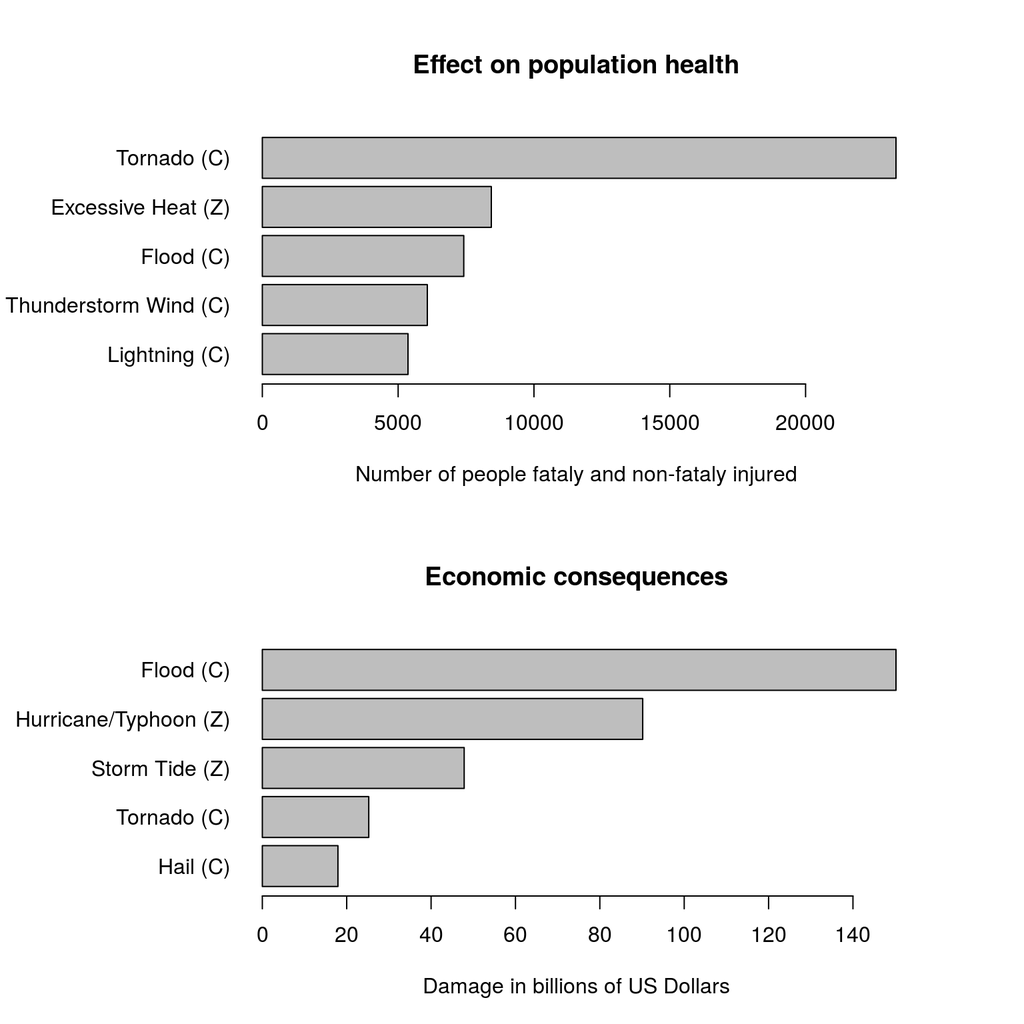

```r
par(mfrow = c(2, 1), mai=c(1,2,1,1))
barplot(health_top10$number_affected[5:1],
        main = "Effect on population health",
        xlab = "Number of people fataly and non-fataly injured",
        names.arg = health_top10$EVTYPE[5:1],
        horiz = TRUE, las = 1)
barplot(damage_top10$damage[5:1]/1000000000,
        main = "Economic consequences",
        xlab = "Damage in billions of US Dollars",
        names.arg = damage_top10$EVTYPE[5:1],
        horiz = TRUE, las = 1)
```

Tornados are by far the most harmfull types of events across the United States, with respect to population health, with a total of fataly and non-fataly injured of over 23000 since 1995. The event type Tornado is followed by Excessive Heat, Flood, Thunderstorm Wind and Lightning, with a combined total of about 27000 since 1995.

Floods are the event types with the greatest economic consequences, with a total damage amount of over 150 billion US Dollar. This is followed by the Hurricane/Typhoon event type, that amounts to a damage of 90 billion US Dollar and Storm Tide with 48 billion US Dollar.